# Data Open Lecture: An Introduction of Python

### Fangda Fan

### Dec 2016

## Contents

- Basic Python Syntax
- Numpy Array for Vectorize Operation
- Pandas DataFrame for Data Analysis
- Statsmodels for Statistical Modeling
- Scikit-learn for Machine Learning
- Review: Data Analysis for Titanic

## Preparation

- Bring your laptop
- Download and Install [Anaconda](https://www.continuum.io/downloads) (Python 3.5 version)
- Open Jupyter Notebook
- Create a new notebook: Right-upper area $\rightarrow$ New $\rightarrow$ Notebooks $\rightarrow$ Python
- Be ready to type in code!

## Our Goal

- Focus on how to *analyze data* with Python
- Not a Python tutorial
- Final Project: Make a good submission on [Titanic](https://www.kaggle.com/c/titanic) of [Kaggle](https://www.kaggle.com/) (a machine learning competition website)

## What is Python?

- A widely used high-level, general-purpose language
- Highly readable
- Abundant Modules
- A [comparsion](https://www.datacamp.com/community/tutorials/r-or-python-for-data-analysis) between Python and R
- A [poll](http://www.kdnuggets.com/polls/2015/r-vs-python.html): Primary programming language for Analytics, Data Mining, Data Science tasks:
  - R: 51% (2015) vs. 46% (2014)
  - Python: 29% (2015) vs. 23% (2014)
  - Others(Java, Matlab, SAS, etc): 17% (2015) vs. 23% (2014)
  - None: 2% (2015) vs. 8% (2014)

```python
import pandas as pd
da = pd.DataFrame([[51, 46], [29, 23], [17, 23], [2, 8]],
                  index = ["R", "Python", "Others", "None"],
                  columns = ["2015", "2014"])
da
```

|  | 2015 | 2014 |
| --- | --- | --- |
| R | 51 | 46 |
| Python | 29 | 23 |
| Others | 17 | 23 |
| None | 2 | 8 |

```python
?da.plot
```

```python
da.mean(axis = 1)
```

```
R         48.5
Python    26.0
Others    20.0
None       5.0
dtype: float64
```

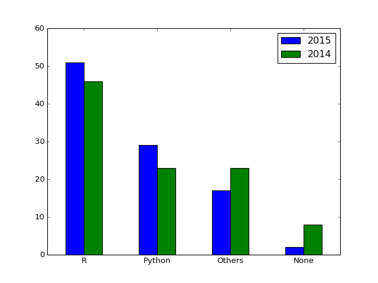

```python
%matplotlib notebook
da.plot(kind = "bar", rot = 0)
```

## How to get help

- From Function Help: ? + function
  - ?pd.DataFrame
  - ?da.plot
- From Books:
  - [Python for Data Analysis](http://www3.canisius.edu/~yany/python/Python4DataAnalysis.pdf), Wes McKinney
  - [Learning Python](http://stock.ethop.org/pdf/python/Learning%20Python,%205th%20Edition.pdf), Mark Lutz
- From Online Course: https://www.datacamp.com/
- From Google: Your Question (what you want to do) + Python
  - read SAS file Python
  - string operation Python

# Basic Python Syntax

## Contents

1. Number
2. String
3. List
   - For-loop
4. Dictionary
5. Tuple
6. Boolean
   - If-else condition
7. Function
8. Other Special Commands

## Basic Python Syntax (1): Number

```python
1 + 2 + 3
```

```
6
```

```python
# compute 4 * 0.5 and save value as variable 'a'
a = 4 * 0.5
a
```

```
2.0
```

```python
# variable 'a' to the power 10
a ** 10
```

```
1024.0
```

```python
(a - 6) / 3
```

```
-1.3333333333333333
```

## Basic Python Syntax (2.1): String

- A string can be created by either ' or "

```python
b = "red apple"
# Select the substring at index 0 (head character)
b[0]
```

```
'r'
```

```python
# Slice from index 4 to 7 (right-side not included)
b[4:7]
```

```
'app'
```

```python
# Slice from index 4
b[4:]
```

```
'apple'
```

```python
# A multi-lines string can be created with triple quotes ''' or """
'''
For the earth shall be full of the knowledge of the LORD
    as the waters cover the sea.
(Isaiah 11:9 ESV)
'''
```

```
'\nFor the earth shall be full of the knowledge of the LORD\n    as the waters cover the sea.\n(Isaiah 11:9 ESV)\n'
```

## Basic Python Syntax (2.2): String Function

```python
# Concatenate string b with another string "green apple"
b + 'green apple'
```

```
'red applegreen apple'
```

```python
# Repeat the same string for 3 times
b * 3
```

```
'red applered applered apple'
```

```python
# Function format() in a string uses a brace '{}' to assign values
"I have {} apples, one is a {}, the other one is also a {}".format(1+1, b, b)
```

```
'I have 2 apples, one is a red apple, the other one is also a red apple'
```

```python
# Split by character
b.split(" ")
```

```
['red', 'apple']
```

```python
# Join by character
"-".join(['red', 'apple'])
```

```
'red-apple'
```

## Basic Python Syntax (3.1): List

- To store more than one values: [value0, value1, value2, ...]
- Values are accessed by position number
- Can contain mixed types of values

```python
# Create a list with a square bracket
c = [1, 3, 5, 7]
c[1]
```

```
3
```

```python
# Slice from index 1 to index 3 (right-side not included)
c[1:3]
```

```
[3, 5]
```

```python
# Change the last value to 9 (-N denotes the Nth index counted from the tail)
c[-1] = 9
c
```

```
[1, 3, 5, 9]
```

```python
# Replace position 1 to 3 with a new list [2, 4, 6, 8]
c[1:3] = [2, 4, 6, 8]
c
```

```
[1, 2, 4, 6, 8, 9]
```

## Basic Python Syntax (3.2): List Function

```python
# Length of list c
len(c)
```

```
6
```

```python
# Concatenate list c with another list (not elementwise plus!)
c + [1, 2, 3, 4, 5, 6]
```

```
[1, 2, 4, 6, 8, 9, 1, 2, 3, 4, 5, 6]
```

```python
# Repeat the same list for 3 times (not elementwise multiply!)
c * 3
```

```
[1, 2, 4, 6, 8, 9, 1, 2, 4, 6, 8, 9, 1, 2, 4, 6, 8, 9]
```

```python
# Append a new element "apple" to the last of list c
c.append("apple")
c
```

```
[1, 2, 4, 6, 8, 9, 'apple']
```

```python
# Insert "red" to position 3 of list c
c.insert(3, "red")
c
```

```
[1, 2, 4, 'red', 6, 8, 9, 'apple']
```

## Basic Python Syntax (3.3): For-loop

```python
# A common for-loop: square of 0 to 9
output = []
for i in range(10):
    value = i ** 2
    output.append(value)
output
```

```
[0, 1, 4, 9, 16, 25, 36, 49, 64, 81]
```

```python
# An list-inside for-loop: square of 0 to 9
[i ** 2 for i in range(10)]
```

```
[0, 1, 4, 9, 16, 25, 36, 49, 64, 81]
```

```python
# An list-inside for-loop with if-conditions
[i ** 2 for i in range(10) if i > 4]
```

```
[25, 36, 49, 64, 81]
```

```python
# Nested List
[[i, j] for i in range(4) for j in range(4) if i > j]
```

```
[[1, 0], [2, 0], [2, 1], [3, 0], [3, 1], [3, 2]]
```

```python
# An list can be directly used as iterator
[i * 3 for i in ["a", "ab", 3, 4, [5, 6]]]
```

```
['aaa', 'ababab', 9, 12, [5, 6, 5, 6, 5, 6]]
```

## Basic Python Syntax (4.1): Dictionary

- To store values with keys: {key0: value0, key1: value1, key2: value2, ...}
- Values are accessed by key, not position number

```python
d = {"name": "gold", "price": 4000}
d
```

```
{'name': 'gold', 'price': 4000}
```

```python
# Select the value with key "name"
d["name"]
```

```
'gold'
```

```python
# Update the value of price by plus 500
d["price"] += 500
d["price"]
```

```
4500
```

```python
# Another way to create a dict: function dict()
dict(R = 51, Python = 29, others = 17, none = 2)
```

```
{'Python': 29, 'R': 51, 'none': 2, 'others': 17}
```

```python
# Create a dict from two lists: function zip()
dict(zip(["R", "Python", "others", "none"], [51, 29, 17, 2]))
```

```
{'Python': 29, 'R': 51, 'none': 2, 'others': 17}
```

## Basic Python Syntax (4.2): Dictionary Functions

```python
# Check all keys of dict d
d.keys()
```

```
dict_keys(['price', 'name'])
```

```python
# Check all values of dict d
d.values()
```

```
dict_values([4500, 'gold'])
```

```python
# Update dict d with another dict
d.update({"price": 6000, "status": "sold out"})
d
```

```
{'name': 'gold', 'price': 6000, 'status': 'sold out'}
```

```python
# List keys of dict d
list(d.keys())
```

```
['status', 'price', 'name']
```

```python
# Remove an element from dict d
d.pop("price")
d
```

```
{'name': 'gold', 'status': 'sold out'}
```

## Basic Python Syntax (5): Tuple

- To store more than one fixed values: (value0, value1, value2, ...)
- Like a list, but cannot be revised

```python
# Check the type of variable a, b, c, d
e = a, b
e
```

```
(2.0, 'red apple')
```

```python
e[0]
```

```
2.0
```

```python
# A tuple cannot be revised
e[2] = 0
```

```
---------------------------------------------------------------------------
TypeError                                 Traceback (most recent call last)
<ipython-input-42-f40e2fa930b4> in <module>()
      1 # A tuple cannot be revised
----> 2 e[2] = 0

TypeError: 'tuple' object does not support item assignment
```

```python
# Switch values of a and b directly
b, a = a, b
a, b
```

```
('red apple', 2.0)
```

## Basic Python Syntax (6.1): Boolean

```python
# Double equal sign "==" means whether two values are equal in value
1 + 1 == 2
```

```
True
```

```python
# sign "!=" means unequal
1 + 1 != 2
```

```
False
```

```python
4 < 3
```

```
False
```

```python
4 >= 8/2
```

```
True
```

```python
# Compare two strings index by index, according to alphabetical sort
"z" > "ab"
```

```
True
```

```python
# "in" find whether a value is in a list
"banana" in ["apple", "banana", 3, 4, 5]
```

```
True
```

## Basic Python Syntax (6.2): If-else

- False logical indicators: False, None, 0, "", [ ], { }

```python
a = 0
if(a):
    print("Hello!")
```

```python
a = []
if(a):
    print("Hello!")
else:
    print("Goodbye!")
```

```
Goodbye!
```

```python
a = [0]
if(a):
    print("Hello!")
else:
    print("Goodbye!")
```

```
Hello!
```

```python
if(type(a) in ["int", "float"]):
    print("a is a number")
elif(type(a) == "str"):
    print("a is a string")
else:
    print("a is neither a number nor a string")
```

```
a is neither a number nor a string
```

## Basic Python Syntax (6.3): Boolean Opeations

- Logical operators (not, and, or): can be used on python built-in types
- Bitwise operators (~, &, |): can be used on numpy bool arrays

```python
# "not": return True if the condition is False
not (1 + 1 == 2)
```

```
False
```

```python
# "or", "|": return True if at least 1 condition is True
(2 > 3) or (2 <= 3)
```

```
True
```

```python
(2 > 3) | (2 <= 3)
```

```
True
```

```python
# "and", "&": return True if both 2 conditions are True
(2 > 3) and (2 <= 3)
```

```
False
```

```python
(2 > 3) & (2 <= 3)
```

```
False
```

## Basic Python Syntax (7): Python Function

- lambda: need no name or return(), usually for short function
- def: need a name and return(), usually for long function and reuse

```python
(lambda x: x + 1)(3)
```

```
4
```

```python
def minus(x, y):
    output = "{} - {} = {}".format(x, y, x-y)
    return(output)
minus(6, 2), minus(x = 5, y = 2), minus(y = 2, x = 3)
```

```
('6 - 2 = 4', '5 - 2 = 3', '3 - 2 = 1')
```

```python
# Set default value to function
def minus(x = 10, y = 3):
    output = "{} - {} = {}".format(x, y, x-y)
    return(output)
minus(), minus(y = 6), minus(x = 4)
```

```
('10 - 3 = 7', '10 - 6 = 4', '4 - 3 = 1')
```

```python
# Use * to expand list, and ** to expand dict
parlist = [8, 1]
pardict = {"x": 14, "y": 9}
minus(*parlist), minus(**pardict)
```

```
('8 - 1 = 7', '14 - 9 = 5')
```

## Basic Python Syntax (8): Other Special Commands

- _: return the last output
- %: run magic syntax of ipython notebook
- !: run system commands

```python
_
```

```
('8 - 1 = 7', '14 - 9 = 5')
```

```python
# %timeit: check running time
%timeit [i**100 for i in range(1000)]
```

```
1000 loops, best of 3: 978 µs per loop
```

```python
# %cd: change working directory
%cd ~/Stat/test/
```

```
/Users/fangda/Stat/test
```

```python
!ls
```

[output not shown]

[output cut: 76 more lines]

[output not shown]

```python
'''
The Value of Wisdom


    For the LORD gives wisdom;

        from his mouth come knowledge and understanding;

    he stores up sound wisdom for the upright;

        he is a shield to those who walk in integrity,

    guarding the paths of justice

        and watching over the way of his saints.



(Proverbs 2:6-8 ESV)
'''
```

# Numpy Array for Vectorize Operation

## Preparation

- Bring your laptop
- Download and Install [Anaconda](https://www.continuum.io/downloads) (Python 3.5 version)
- Open Jupyter Notebook
- Open saved notebook last time
  - or create a new notebook: Right-upper area $\rightarrow$ New $\rightarrow$ Notebooks $\rightarrow$ Python
- Be ready to type in code!

## What is Numpy

- A fundamental package for scientific computing with Python.
- It contains among other things:
  - A powerful N-dimensional array object
  - Sophisticated (broadcasting) functions
  - Tools for integrating C/C++ and Fortran code
  - Useful linear algebra, Fourier transform, and random number capabilities

Reference: [Numpy official website](http://www.numpy.org/)

## Contents

1. Vectorize Operations
2. Numeric Functions
3. Set Operations
4. Generate Arrays
5. 2D Array (Matrix)
6. Axis-wise Functions
7. Linear Algebra
8. Reshape and Concatenate
9. Missing Values and Infinity

## Numpy Array (1): Vectorize Operations

```python
import numpy as np
x = np.array([-1, 0, 2, 5])
x
```

```
array([-1,  0,  2,  5])
```

```python
x + [1, 2, 3, 4]
```

```
array([0, 2, 5, 9])
```

```python
x * 3
```

```
array([-3,  0,  6, 15])
```

```python
# Index and slice like a list (-N denotes the Nth index counted from the tail)
x[:-1]
```

```
array([-1,  0,  2])
```

```python
# Index and slice by boolean condition
x[x > 0]
```

```
array([2, 5])
```

```python
# shape allows for showing more than 1 dimensions
x.shape
```

```
(4,)
```

## Numpy Array (2): Numeric Functions

```python
# Maximum and minimum
x.max(), x.min()
```

```
(5, -1)
```

```python
# The index of maximum and minimum
x.argmax(), x.argmin()
```

```
(3, 0)
```

```python
# Sum, mean, variance and standard deviation
x.sum(), x.mean(), x.var(), x.std()
```

```
(6, 1.5, 5.25, 2.2912878474779199)
```

```python
# Cumulative sum
np.cumsum(x)
```

```
array([-1, -1,  1,  6])
```

```python
# Difference
np.diff(x)
```

```
array([1, 2, 3])
```

## How to get help

- From Function Help: ? + function
  - ?np.diff
  - ?da.head
- From Autofill with *Tab*:
  - np. + *Tab*
  - (a numpy array). + *Tab*
- From Google: Your Question (what you want to do) + numpy
  - upper triangular matrix numpy
  - convolution numpy
- From Official Website: http://www.numpy.org/
- From Online Course: https://www.datacamp.com/
- From Book: [Python for Data Analysis](http://www3.canisius.edu/~yany/python/Python4DataAnalysis.pdf), Wes McKinney

## Numpy Array (3): Set Operations

```python
# Find unique element and sort them
z = np.unique([1, 2, 1, 0, 5, 5])
z
```

```
array([0, 1, 2, 5])
```

```python
# Set union
np.union1d(x, z)
```

```
array([-1,  0,  1,  2,  5])
```

```python
# Set intersect
np.intersect1d(x, z)
```

```
array([0, 2, 5])
```

```python
# Set exclusive values in x
np.setdiff1d(x, z)
```

```
array([-1])
```

```python
# Set exclusive values in x and z
np.setxor1d(x, z)
```

```
array([-1,  1])
```

## Numpy Array (4): Generate Arrays

```python
# Generate all 1 array of shape [row, column] = [2, 3]
np.ones([2, 3])
```

```
array([[ 1.,  1.,  1.],
       [ 1.,  1.,  1.]])
```

```python
# Repeat each value in a list for 3 times
np.repeat(x, 3)
```

```
array([-1, -1, -1,  0,  0,  0,  2,  2,  2,  5,  5,  5])
```

```python
# Generate a sequence from 4 to 20 (right-side not included) with step-size 2
np.arange(4, 20, 2)
```

```
array([ 4,  6,  8, 10, 12, 14, 16, 18])
```

```python
# Generate a uniform random sample between 2 and 3 of length 5
np.random.seed(1)
np.random.uniform(low = 2, high = 3, size = 5)
```

```
array([ 2.417022  ,  2.72032449,  2.00011437,  2.30233257,  2.14675589])
```

```python
# Random sample from a list
np.random.choice(x, size = 10)
```

```
array([-1,  0, -1,  5,  0, -1,  2,  0,  2, -1])
```

## Numpy Array (5): 2D Array (Matrix)

```python
y = np.array([[1, 2, 3, 4], [5, 6, 7, 8], [9, 10, 11, 12]])
y
```

```
array([[ 1,  2,  3,  4],
       [ 5,  6,  7,  8],
       [ 9, 10, 11, 12]])
```

```python
# Select by row 2 and column 0
y[2,0]
```

```
9
```

```python
# Slice a sub-matrix by row 0 to 2 and column 1 to 3
y[0:2, 1:3]
```

```
array([[2, 3],
       [6, 7]])
```

```python
# Slice a sub-matrix by all row and column 2 to last
y[:, 2:]
```

```
array([[ 3,  4],
       [ 7,  8],
       [11, 12]])
```

## Numpy Array (6): Axis-wise Function

```python
# axis = 0: sum all rows
y.sum(axis = 0)
```

```
array([15, 18, 21, 24])
```

```python
# axis = 1: sum all columns
y.sum(axis = 1)
```

```
array([10, 26, 42])
```

```python
# default: sum all entries
y.sum()
```

```
78
```

```python
# If each row has any columns satisfying condition
(y > 5).any(axis = 1)
```

```
array([False,  True,  True], dtype=bool)
```

```python
# If each row has all columns satisfying condition
(y > 5).all(axis = 1)
```

```
array([False, False,  True], dtype=bool)
```

## Numpy Array (7): Linear Algebra

```python
# Transpose
y.T
```

```
array([[ 1,  5,  9],
       [ 2,  6, 10],
       [ 3,  7, 11],
       [ 4,  8, 12]])
```

```python
# Element-wise product on each row
y * x
```

```
array([[-1,  0,  6, 20],
       [-5,  0, 14, 40],
       [-9,  0, 22, 60]])
```

```python
# Dot product of matrix
y.dot(x)
```

```
array([25, 49, 73])
```

```python
# Eigen-decomposition of yy'
y2 = y.dot(y.T)
np.linalg.eig(y2)
```

```
(array([  6.47032607e+02,   2.96739296e+00,   4.87870499e-14]),
 array([[-0.20673589, -0.88915331,  0.40824829],
        [-0.51828874, -0.25438183, -0.81649658],
        [-0.82984158,  0.38038964,  0.40824829]]))
```

## Numpy Array (8): Reshape and Concatenate

```python
# Reshape an array to another shape
y.reshape([2, 6])
```

```
array([[ 1,  2,  3,  4,  5,  6],
       [ 7,  8,  9, 10, 11, 12]])
```

```python
# Extend the dimension of 1d-array with np.newaxis
x[:, np.newaxis]
```

```
array([[-1],
       [ 0],
       [ 2],
       [ 5]])
```

```python
# Concatenate two 2d-arrays along columns (axis = 1)
np.concatenate([y, y], axis = 1)
```

```
array([[ 1,  2,  3,  4,  1,  2,  3,  4],
       [ 5,  6,  7,  8,  5,  6,  7,  8],
       [ 9, 10, 11, 12,  9, 10, 11, 12]])
```

```python
# Concatenate 2d-array y with 1d-array x, need to add a dimension to x first
np.concatenate([y, [x]])
```

```
array([[ 1,  2,  3,  4],
       [ 5,  6,  7,  8],
       [ 9, 10, 11, 12],
       [-1,  0,  2,  5]])
```

## Numpy Array (9): Missing Values and Infinity

- np.nan: missing value
- np.inf: (positive) infinity

```python
e = np.array([np.nan, np.inf, -np.inf, 2, 3])
e
```

```
array([ nan,  inf, -inf,   2.,   3.])
```

```python
# inf and -inf are different values, to find both we use np.inf()
e == np.inf
```

```
array([False,  True, False, False, False], dtype=bool)
```

```python
np.isinf(e)
```

```
array([False,  True,  True, False, False], dtype=bool)
```

```python
# We cannot find nan value by "== np.nan", instead we use np.isnan()
e == np.nan
```

```
array([False, False, False, False, False], dtype=bool)
```

```python
np.isnan(e)
```

```
array([ True, False, False, False, False], dtype=bool)
```

```python
'''
The Blessings of Wisdom


    When he made firm the skies above,

        when he established the fountains of the deep,

    when he assigned to the sea its limit,

        so that the waters might not transgress his command,

    when he marked out the foundations of the earth,

        then I was beside him, like a master workman,

    and I was daily his delight,

        rejoicing before him always,

    rejoicing in his inhabited world

        and delighting in the children of man.


(Proverbs 8:28-31 ESV)
'''
```

# Pandas DataFrame for Data Analysis

## Preparation

- Bring your laptop
- Download and Install [Anaconda](https://www.continuum.io/downloads) (Python 3.5 version)
- Download file "Diamonds.csv" from [lecture repository](https://github.com/founderfan/Data-Open-Lecture)
- Open Jupyter Notebook
- Open saved notebook last time
  - or create a new notebook: Right-upper area $\rightarrow$ New $\rightarrow$ Notebooks $\rightarrow$ Python
- Be ready to type in code!

## What is Pandas

- An open source, BSD-licensed library for Python.
- Providing high-performance, easy-to-use data structures and data analysis tools

Reference: [Pandas official site](http://pandas.pydata.org/)

## Contents

1. Read Data
2. Data Types
3. Data Values
4. Index and Sort
5. Descriptive Analysis
   - Univariate and Bivariate
   - Numeric and Categorical
   - Tables and Plots
6. Apply
7. Missing Values
8. Groupby
9. Concatenate
10. Output

## Pandas DataFrame (1): Read Data

```python
# Load modules and set options
import numpy as np
import pandas as pd
import matplotlib.pyplot as plt

pd.set_option('precision', 3)
%matplotlib notebook
%cd ~/Stat
```

```
/Users/fangda/Stat
```

```python
# pd.read_csv(): Read dataset "Diamonds"
da = pd.read_csv("Diamonds.csv")
da.shape
```

```
(53940, 11)
```

```python
# head(): Head of data
da.head()
```

|  | n | carat | cut | color | clarity | depth | table | price | x | y | z |
| --- | --- | --- | --- | --- | --- | --- | --- | --- | --- | --- | --- |
| 0 | 1 | 0.23 | Ideal | E | SI2 | 61.5 | 55.0 | NaN | 3.95 | 3.98 | 2.43 |
| 1 | 2 | 0.21 | Premium | E | SI1 | 59.8 | 61.0 | 326.0 | 3.89 | 3.84 | 2.31 |
| 2 | 3 | 0.23 | Good | E | VS1 | 56.9 | 65.0 | NaN | 4.05 | 4.07 | 2.31 |
| 3 | 4 | 0.29 | Premium | I | VS2 | 62.4 | 58.0 | 334.0 | 4.20 | 4.23 | 2.63 |
| 4 | 5 | 0.31 | Good | J | SI2 | 63.3 | 58.0 | 335.0 | 4.34 | 4.35 | 2.75 |

## How to get help

- From Function Help: ? + function
  - ?pd.read_csv
  - ?da.head
- From Autofill with *Tab*:
  - pd. + *Tab*
  - (a pandas object). + *Tab*
- From Google: Your Question (what you want to do) + Pandas (DataFrame)
  - combine two DataFrames pandas
  - select a part of strings pandas
- From Official Website: http://pandas.pydata.org/
- From Online Course: https://www.datacamp.com/
- From Book: [Python for Data Analysis](http://www3.canisius.edu/~yany/python/Python4DataAnalysis.pdf), Wes McKinney

## Pandas DataFrame (2): Data Types

- Numeric: float, int (64 bits most often)
- Categorical: object
- Date/Time: datetime

```python
da.dtypes
```

```
n            int64
carat      float64
cut         object
color       object
clarity     object
depth      float64
table      float64
price      float64
x          float64
y          float64
z          float64
dtype: object
```

```python
# Detailed data information
da.info()
```

```
<class 'pandas.core.frame.DataFrame'>
RangeIndex: 53940 entries, 0 to 53939
Data columns (total 11 columns):
n          53940 non-null int64
carat      53940 non-null float64
cut        53940 non-null object
color      53940 non-null object
clarity    53940 non-null object
depth      53940 non-null float64
table      53940 non-null float64
price      39708 non-null float64
x          53940 non-null float64
y          53940 non-null float64
z          53940 non-null float64
dtypes: float64(7), int64(1), object(3)
memory usage: 4.5+ MB
```

## Pandas DataFrame (3.1): Data Values

- The values of Pandas Series/DataFrame are based on 1D/2D numpy array

```python
# Select a column by name, and get a pandas Series
da["carat"].head()
```

```
0    0.23
1    0.21
2    0.23
3    0.29
4    0.31
Name: carat, dtype: float64
```

```python
da["carat"].values
```

```
array([ 0.23,  0.21,  0.23, ...,  0.7 ,  0.86,  0.75])
```

```python
da.values
```

```
array([[1, 0.23, 'Ideal', ..., 3.95, 3.98, 2.43],
       [2, 0.21, 'Premium', ..., 3.89, 3.84, 2.31],
       [3, 0.23, 'Good', ..., 4.05, 4.07, 2.31],
       ...,
       [53938, 0.7, 'Very Good', ..., 5.66, 5.68, 3.56],
       [53939, 0.86, 'Premium', ..., 6.15, 6.12, 3.74],
       [53940, 0.75, 'Ideal', ..., 5.83, 5.87, 3.64]], dtype=object)
```

## Pandas DataFrame (3.2): Assign Values

- DF[] = value: assign/revise a column in DataFrame directly
- DF.assign(**kwargs): assign/revise column(s) and return a new DataFrame

```python
da["heavy"] = da["carat"] > 0.5
da
```

|  | n | carat | cut | color | clarity | depth | table | price | x | y | z | heavy |
| --- | --- | --- | --- | --- | --- | --- | --- | --- | --- | --- | --- | --- |
| 0 | 1 | 0.23 | Ideal | E | SI2 | 61.5 | 55.0 | NaN | 3.95 | 3.98 | 2.43 | False |
| 1 | 2 | 0.21 | Premium | E | SI1 | 59.8 | 61.0 | 326.0 | 3.89 | 3.84 | 2.31 | False |
| ... | ... | ... | ... | ... | ... | ... | ... | ... | ... | ... | ... | ... |
| 53938 | 53939 | 0.86 | Premium | H | SI2 | 61.0 | 58.0 | 2757.0 | 6.15 | 6.12 | 3.74 | True |
| 53939 | 53940 | 0.75 | Ideal | D | SI2 | 62.2 | 55.0 | NaN | 5.83 | 5.87 | 3.64 | True |

53940 rows × 12 columns

```python
da.assign(intercept = 1, volume = lambda x: x["x"]*x["y"]*x["z"])
```

|  | n | carat | cut | color | clarity | depth | table | price | x | y | z | heavy | intercept | volume |
| --- | --- | --- | --- | --- | --- | --- | --- | --- | --- | --- | --- | --- | --- | --- |
| 0 | 1 | 0.23 | Ideal | E | SI2 | 61.5 | 55.0 | NaN | 3.95 | 3.98 | 2.43 | False | 1 | 38.202 |
| 1 | 2 | 0.21 | Premium | E | SI1 | 59.8 | 61.0 | 326.0 | 3.89 | 3.84 | 2.31 | False | 1 | 34.506 |
| ... | ... | ... | ... | ... | ... | ... | ... | ... | ... | ... | ... | ... | ... | ... |
| 53938 | 53939 | 0.86 | Premium | H | SI2 | 61.0 | 58.0 | 2757.0 | 6.15 | 6.12 | 3.74 | True | 1 | 140.766 |
| 53939 | 53940 | 0.75 | Ideal | D | SI2 | 62.2 | 55.0 | NaN | 5.83 | 5.87 | 3.64 | True | 1 | 124.568 |

53940 rows × 14 columns

## Pandas DataFrame (4.1): Index

```python
# DF.set_index(keys): Set column(s) as index for rows
da = da.set_index("n")
da
```

| n | carat | cut | color | clarity | depth | table | price | x | y | z | heavy |
| --- | --- | --- | --- | --- | --- | --- | --- | --- | --- | --- | --- |
| 1 | 0.23 | Ideal | E | SI2 | 61.5 | 55.0 | NaN | 3.95 | 3.98 | 2.43 | False |
| 2 | 0.21 | Premium | E | SI1 | 59.8 | 61.0 | 326.0 | 3.89 | 3.84 | 2.31 | False |
| ... | ... | ... | ... | ... | ... | ... | ... | ... | ... | ... | ... |
| 53939 | 0.86 | Premium | H | SI2 | 61.0 | 58.0 | 2757.0 | 6.15 | 6.12 | 3.74 | True |
| 53940 | 0.75 | Ideal | D | SI2 | 62.2 | 55.0 | NaN | 5.83 | 5.87 | 3.64 | True |

53940 rows × 11 columns

```python
# Check the index of rows and columns
da.index, da.columns
```

```
(Int64Index([    1,     2,     3,     4,     5,     6,     7,     8,     9,
                10,
             ...
             53931, 53932, 53933, 53934, 53935, 53936, 53937, 53938, 53939,
             53940],
            dtype='int64', name='n', length=53940),
 Index(['carat', 'cut', 'color', 'clarity', 'depth', 'table', 'price', 'x', 'y',
        'z', 'heavy'],
       dtype='object'))
```

## Pandas DataFrame (4.2): Indexing methods

- iloc[]: Indexing by index number like numpy array (right-edge not included)
- loc[]: indexing by either name or boolean

```python
da.iloc[1:2, 2:7]
```

| n | color | clarity | depth | table | price |
| --- | --- | --- | --- | --- | --- |
| 2 | E | SI1 | 59.8 | 61.0 | 326.0 |

```python
da.loc[1:2, "color":"x"]
```

| n | color | clarity | depth | table | price | x |
| --- | --- | --- | --- | --- | --- | --- |
| 1 | E | SI2 | 61.5 | 55.0 | NaN | 3.95 |
| 2 | E | SI1 | 59.8 | 61.0 | 326.0 | 3.89 |

```python
da.loc[da["color"] == "G", da.dtypes == "object"]
```

| n | cut | color | clarity |
| --- | --- | --- | --- |
| 26 | Very Good | G | VVS2 |
| 52 | Ideal | G | VS1 |
| ... | ... | ... | ... |
| 53914 | Good | G | VS2 |
| 53930 | Ideal | G | VS1 |

11292 rows × 3 columns

## Pandas DataFrame (4.3): Sort

- DF.sort_index(axis, level, ascending): sort by index
- DF.sort_values(by, axis, ascending): sort by values in column(s)

```python
da.sort_index(ascending = False)
```

| n | carat | cut | color | clarity | depth | table | price | x | y | z | heavy |
| --- | --- | --- | --- | --- | --- | --- | --- | --- | --- | --- | --- |
| 53940 | 0.75 | Ideal | D | SI2 | 62.2 | 55.0 | NaN | 5.83 | 5.87 | 3.64 | True |
| 53939 | 0.86 | Premium | H | SI2 | 61.0 | 58.0 | 2757.0 | 6.15 | 6.12 | 3.74 | True |
| ... | ... | ... | ... | ... | ... | ... | ... | ... | ... | ... | ... |
| 2 | 0.21 | Premium | E | SI1 | 59.8 | 61.0 | 326.0 | 3.89 | 3.84 | 2.31 | False |
| 1 | 0.23 | Ideal | E | SI2 | 61.5 | 55.0 | NaN | 3.95 | 3.98 | 2.43 | False |

53940 rows × 11 columns

```python
da.sort_values("carat", ascending = False)
```

| n | carat | cut | color | clarity | depth | table | price | x | y | z | heavy |
| --- | --- | --- | --- | --- | --- | --- | --- | --- | --- | --- | --- |
| 27416 | 5.01 | Fair | J | I1 | 65.5 | 59.0 | NaN | 10.74 | 10.54 | 6.98 | True |
| 27631 | 4.50 | Fair | J | I1 | 65.8 | 58.0 | NaN | 10.23 | 10.16 | 6.72 | True |
| ... | ... | ... | ... | ... | ... | ... | ... | ... | ... | ... | ... |
| 15 | 0.20 | Premium | E | SI2 | 60.2 | 62.0 | NaN | 3.79 | 3.75 | 2.27 | False |
| 31597 | 0.20 | Premium | F | VS2 | 62.6 | 59.0 | 367.0 | 3.73 | 3.71 | 2.33 | False |

53940 rows × 11 columns

## Pandas DataFrame (5.1.1): Univariate Description: Numeric

- Summary statistics: DF.describe()
- Histogram plot: DF.hist(column, by, bins)

```python
da.describe()
```

|  | carat | depth | table | price | x | y | z |
| --- | --- | --- | --- | --- | --- | --- | --- |
| count | 53940.000 | 53940.000 | 53940.000 | 39708.00 | 53940.000 | 53940.000 | 53940.000 |
| mean | 0.798 | 61.749 | 57.457 | 3928.36 | 5.731 | 5.735 | 3.539 |
| ... | ... | ... | ... | ... | ... | ... | ... |
| 75% | 1.040 | 62.500 | 59.000 | 5302.25 | 6.540 | 6.540 | 4.040 |
| max | 5.010 | 79.000 | 95.000 | 18818.00 | 10.740 | 58.900 | 31.800 |

8 rows × 7 columns

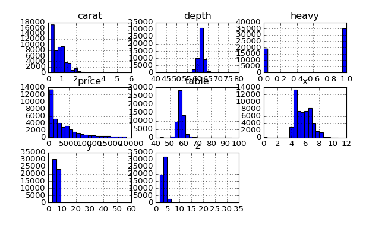

[output not shown]

```python
da.hist(bins = 20)
```

## Pandas DataFrame (5.1.2): Univariate Description: Categorical

- Count values of each category: pd.value_counts(values)
- Bar-plot: pd.value_counts(values).plot(kind = "bar")

```python
s = pd.value_counts(da["cut"])
s
```

```
Ideal        21551
Premium      13791
Very Good    12082
Good          4906
Fair          1610
Name: cut, dtype: int64
```

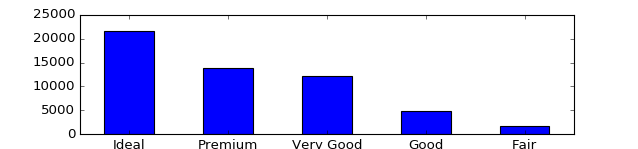

```python
s.plot(kind = "bar", rot = 0)
```

## Pandas DataFrame (5.2.1): Bivariate Description: Num-Num

- correlation matrix: DF.corr()
- scatter plot: DF.plot(x, y, kind = "scatter")

```python
da.corr()
```

|  | carat | depth | table | price | x | y | z | heavy |
| --- | --- | --- | --- | --- | --- | --- | --- | --- |
| carat | 1.000 | 0.028 | 0.182 | 0.923 | 0.975 | 0.952 | 0.953 | 0.687 |
| depth | 0.028 | 1.000 | -0.296 | -0.012 | -0.025 | -0.029 | 0.095 | 0.016 |
| ... | ... | ... | ... | ... | ... | ... | ... | ... |
| z | 0.953 | 0.095 | 0.151 | 0.874 | 0.971 | 0.952 | 1.000 | 0.769 |
| heavy | 0.687 | 0.016 | 0.148 | 0.570 | 0.784 | 0.767 | 0.769 | 1.000 |

8 rows × 8 columns

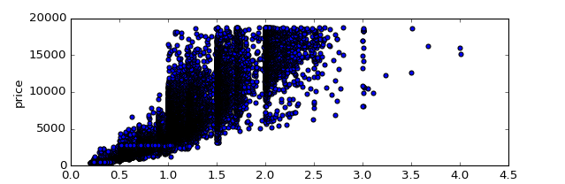

```python
da.plot(x = "carat", y = "price", kind = "scatter", ylim = [0, 20000])
```

## Pandas DataFrame (5.2.2): Bivariate Description: Cat-Num

- Grouped summary statistics: DF.groupby(by)
- Boxplot: DF.boxplot(column, by)

```python
da.groupby("cut").mean()
```

| cut | carat | depth | table | price | x | y | z | heavy |
| --- | --- | --- | --- | --- | --- | --- | --- | --- |
| Fair | 1.046 | 64.042 | 59.054 | 4358.958 | 6.247 | 6.183 | 3.983 | 0.880 |
| Good | 0.849 | 62.366 | 58.695 | 3927.028 | 5.839 | 5.851 | 3.640 | 0.718 |
| Ideal | 0.703 | 61.709 | 55.952 | 3456.976 | 5.507 | 5.520 | 3.401 | 0.575 |
| Premium | 0.892 | 61.265 | 58.746 | 4595.610 | 5.974 | 5.945 | 3.647 | 0.687 |
| Very Good | 0.806 | 61.818 | 57.956 | 3951.410 | 5.741 | 5.770 | 3.560 | 0.678 |

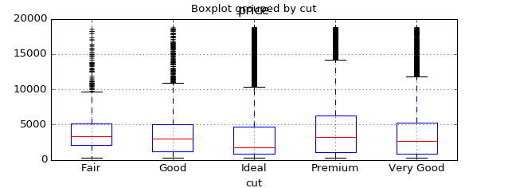

```python
da.boxplot(column = "price", by = "cut")
```

## Pandas DataFrame (5.2.3): Bivariate Description: Cat-Cat

- cross table: pd.crosstab(index, columns)
- grouped line plot: pd.crosstab(index, columns).plot()

```python
s = pd.crosstab(da["cut"], da["color"])
s
```

| color cut | D | E | F | G | H | I | J |
| --- | --- | --- | --- | --- | --- | --- | --- |
| Fair | 163 | 224 | 312 | 314 | 303 | 175 | 119 |
| Good | 662 | 933 | 909 | 871 | 702 | 522 | 307 |
| Ideal | 2834 | 3903 | 3826 | 4884 | 3115 | 2093 | 896 |
| Premium | 1603 | 2337 | 2331 | 2924 | 2360 | 1428 | 808 |
| Very Good | 1513 | 2400 | 2164 | 2299 | 1824 | 1204 | 678 |

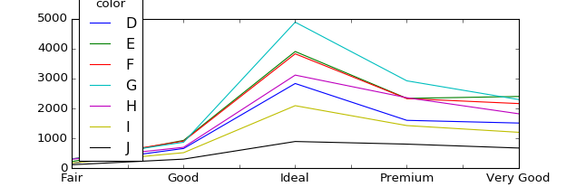

```python
s.plot()
```

## Pandas DataFrame (6): Apply

- DT.apply(func, axis): Apply vector functions to each column/row of DataFrame

```python
# Apply function to each column: 5 most frequent values
da.apply(lambda x: pd.Series(pd.value_counts(x).index[:5]))
```

|  | carat | cut | color | clarity | depth | table | price | x | y | z | heavy |
| --- | --- | --- | --- | --- | --- | --- | --- | --- | --- | --- | --- |
| 0 | 0.30 | Ideal | G | SI1 | 62.0 | 56.0 | 605.0 | 4.37 | 4.34 | 2.70 | True |
| 1 | 0.31 | Premium | E | VS2 | 61.9 | 57.0 | 828.0 | 4.34 | 4.37 | 2.69 | False |
| 2 | 1.01 | Very Good | F | SI2 | 61.8 | 58.0 | 776.0 | 4.33 | 4.35 | 2.71 | NaN |
| 3 | 0.70 | Good | H | VS1 | 62.2 | 59.0 | 789.0 | 4.38 | 4.33 | 2.68 | NaN |
| 4 | 0.32 | Fair | D | VVS2 | 62.1 | 55.0 | 666.0 | 4.32 | 4.32 | 2.72 | NaN |

```python
# The Frequency of 5 most frequent values
da.apply(lambda x: pd.Series(pd.value_counts(x).values[:5]))
```

|  | carat | cut | color | clarity | depth | table | price | x | y | z | heavy |
| --- | --- | --- | --- | --- | --- | --- | --- | --- | --- | --- | --- |
| 0 | 2604 | 21551 | 11292 | 13065 | 2239 | 9881 | 103 | 448 | 437 | 767 | 35008.0 |
| 1 | 2249 | 13791 | 9797 | 12258 | 2163 | 9724 | 96 | 437 | 435 | 748 | 18932.0 |
| 2 | 2242 | 12082 | 9542 | 9194 | 2077 | 8369 | 95 | 429 | 425 | 738 | NaN |
| 3 | 1981 | 4906 | 8304 | 8171 | 2039 | 6572 | 91 | 428 | 421 | 730 | NaN |
| 4 | 1840 | 1610 | 6775 | 5066 | 2020 | 6268 | 88 | 425 | 414 | 697 | NaN |

## Pandas DataFrame (7): Missing Values

- Find missing values (np.nan): DF.isnull()
- Fill missing values (np.nan): DF.fillna(value, method, axis)
- Drop missing values (np.nan): DF.dropna(axis, how)

```python
da.fillna(da.mean())
```

| n | carat | cut | color | clarity | depth | table | price | x | y | z | heavy |
| --- | --- | --- | --- | --- | --- | --- | --- | --- | --- | --- | --- |
| 1 | 0.23 | Ideal | E | SI2 | 61.5 | 55.0 | 3928.36 | 3.95 | 3.98 | 2.43 | False |
| 2 | 0.21 | Premium | E | SI1 | 59.8 | 61.0 | 326.00 | 3.89 | 3.84 | 2.31 | False |
| ... | ... | ... | ... | ... | ... | ... | ... | ... | ... | ... | ... |
| 53939 | 0.86 | Premium | H | SI2 | 61.0 | 58.0 | 2757.00 | 6.15 | 6.12 | 3.74 | True |
| 53940 | 0.75 | Ideal | D | SI2 | 62.2 | 55.0 | 3928.36 | 5.83 | 5.87 | 3.64 | True |

53940 rows × 11 columns

```python
da.dropna()
```

| n | carat | cut | color | clarity | depth | table | price | x | y | z | heavy |
| --- | --- | --- | --- | --- | --- | --- | --- | --- | --- | --- | --- |
| 2 | 0.21 | Premium | E | SI1 | 59.8 | 61.0 | 326.0 | 3.89 | 3.84 | 2.31 | False |
| 4 | 0.29 | Premium | I | VS2 | 62.4 | 58.0 | 334.0 | 4.20 | 4.23 | 2.63 | False |
| ... | ... | ... | ... | ... | ... | ... | ... | ... | ... | ... | ... |
| 53937 | 0.72 | Good | D | SI1 | 63.1 | 55.0 | 2757.0 | 5.69 | 5.75 | 3.61 | True |
| 53939 | 0.86 | Premium | H | SI2 | 61.0 | 58.0 | 2757.0 | 6.15 | 6.12 | 3.74 | True |

39708 rows × 11 columns

## Pandas DataFrame (8): Groupby

- DF.groupby(by): create a group of dataframes for function apply
- DF.aggregate(arg): apply any function(s) on a groupby object

```python
group = da.groupby(["cut"])
group.mean()
```

| cut | carat | depth | table | price | x | y | z | heavy |
| --- | --- | --- | --- | --- | --- | --- | --- | --- |
| Fair | 1.046 | 64.042 | 59.054 | 4358.958 | 6.247 | 6.183 | 3.983 | 0.880 |
| Good | 0.849 | 62.366 | 58.695 | 3927.028 | 5.839 | 5.851 | 3.640 | 0.718 |
| Ideal | 0.703 | 61.709 | 55.952 | 3456.976 | 5.507 | 5.520 | 3.401 | 0.575 |
| Premium | 0.892 | 61.265 | 58.746 | 4595.610 | 5.974 | 5.945 | 3.647 | 0.687 |
| Very Good | 0.806 | 61.818 | 57.956 | 3951.410 | 5.741 | 5.770 | 3.560 | 0.678 |

```python
group.aggregate([np.mean, np.std])
```

| cut | carat mean | carat std | depth mean | depth std | table mean | table std | price mean | price std | x mean | x std | y mean | y std | z mean | z std | heavy mean | heavy std |
| --- | --- | --- | --- | --- | --- | --- | --- | --- | --- | --- | --- | --- | --- | --- | --- | --- |
| Fair | 1.046 | 0.516 | 64.042 | 3.643 | 59.054 | 3.946 | 4358.958 | 3498.143 | 6.247 | 0.964 | 6.183 | 0.956 | 3.983 | 0.652 | 0.880 | 0.325 |
| Good | 0.849 | 0.454 | 62.366 | 2.169 | 58.695 | 2.851 | 3927.028 | 3691.613 | 5.839 | 1.057 | 5.851 | 1.052 | 3.640 | 0.655 | 0.718 | 0.450 |
| Ideal | 0.703 | 0.433 | 61.709 | 0.719 | 55.952 | 1.246 | 3456.976 | 3821.225 | 5.507 | 1.064 | 5.520 | 1.074 | 3.401 | 0.658 | 0.575 | 0.494 |
| Premium | 0.892 | 0.515 | 61.265 | 1.159 | 58.746 | 1.479 | 4595.610 | 4364.236 | 5.974 | 1.188 | 5.945 | 1.260 | 3.647 | 0.731 | 0.687 | 0.464 |
| Very Good | 0.806 | 0.459 | 61.818 | 1.379 | 57.956 | 2.121 | 3951.410 | 3911.626 | 5.741 | 1.101 | 5.770 | 1.103 | 3.560 | 0.730 | 0.678 | 0.467 |

## Pandas DataFrame (9): Concatenate

- pd.concat(objs, axis, join, keys): join multiple DataFrames/Series by row/column
- DT.join(other, on, how): join a DataFrame with another by column

```python
s = da.dtypes.rename("Type")
pd.concat([da.describe().T, s], axis = 1)
```

|  | count | mean | std | min | 25% | 50% | 75% | max | Type |
| --- | --- | --- | --- | --- | --- | --- | --- | --- | --- |
| carat | 53940.0 | 0.798 | 0.474 | 0.2 | 0.40 | 0.70 | 1.04 | 5.01 | float64 |
| clarity | NaN | NaN | NaN | NaN | NaN | NaN | NaN | NaN | object |
| ... | ... | ... | ... | ... | ... | ... | ... | ... | ... |
| y | 53940.0 | 5.735 | 1.142 | 0.0 | 4.72 | 5.71 | 6.54 | 58.90 | float64 |
| z | 53940.0 | 3.539 | 0.706 | 0.0 | 2.91 | 3.53 | 4.04 | 31.80 | float64 |

11 rows × 9 columns

```python
da.describe().T.join(s)
```

|  | count | mean | std | min | 25% | 50% | 75% | max | Type |
| --- | --- | --- | --- | --- | --- | --- | --- | --- | --- |
| carat | 53940.0 | 0.798 | 0.474 | 0.2 | 0.40 | 0.70 | 1.04 | 5.01 | float64 |
| depth | 53940.0 | 61.749 | 1.433 | 43.0 | 61.00 | 61.80 | 62.50 | 79.00 | float64 |
| ... | ... | ... | ... | ... | ... | ... | ... | ... | ... |
| y | 53940.0 | 5.735 | 1.142 | 0.0 | 4.72 | 5.71 | 6.54 | 58.90 | float64 |
| z | 53940.0 | 3.539 | 0.706 | 0.0 | 2.91 | 3.53 | 4.04 | 31.80 | float64 |

7 rows × 9 columns

## Pandas DataFrame (10): Output

- DT.to_csv(path_or_buf, sep, index): write a csv file, easy and general
- DT.to_hdf(path_or_buf, key, complevel): faster for big data with dtypes saved, a key is required

```python
da.describe().T.to_csv("Diamonds_summary.csv")
```

```python
da.to_hdf("Diamonds_hdf.h5", key = "Diamonds")
```

```python
pd.read_hdf("Diamonds_hdf.h5", key = "Diamonds")
```

| n | carat | cut | color | clarity | depth | table | price | x | y | z | heavy |
| --- | --- | --- | --- | --- | --- | --- | --- | --- | --- | --- | --- |
| 1 | 0.23 | Ideal | E | SI2 | 61.5 | 55.0 | NaN | 3.95 | 3.98 | 2.43 | False |
| 2 | 0.21 | Premium | E | SI1 | 59.8 | 61.0 | 326.0 | 3.89 | 3.84 | 2.31 | False |
| ... | ... | ... | ... | ... | ... | ... | ... | ... | ... | ... | ... |
| 53939 | 0.86 | Premium | H | SI2 | 61.0 | 58.0 | 2757.0 | 6.15 | 6.12 | 3.74 | True |
| 53940 | 0.75 | Ideal | D | SI2 | 62.2 | 55.0 | NaN | 5.83 | 5.87 | 3.64 | True |

53940 rows × 11 columns

```python
'''
For to Us a Child Is Born


    For to us a child is born,

        to us a son is given;

    and the government shall be upon his shoulder,

        and his name shall be called

    Wonderful Counselor, Mighty God,

        Everlasting Father, Prince of Peace.



(Isaiah 9:6 ESV)
'''
```

# Statsmodels for Statistical Modeling

## Preparation

- Bring your laptop
- Download and Install [Anaconda](https://www.continuum.io/downloads) (Python 3.5 version)
- Download file "Diamonds.csv" from [lecture repository](https://github.com/founderfan/Data-Open-Lecture)
- Open Jupyter Notebook
- Open saved notebook last time
  - or create a new notebook: Right-upper area $\rightarrow$ New $\rightarrow$ Notebooks $\rightarrow$ Python
- Be ready to type in code!

## What is Statsmodels

- A Python module that allows users to
  - explore data
  - estimate statistical models
  - perform statistical tests

Reference: [Statsmodels official site](http://statsmodels.sourceforge.net/)

## Contents

1. Linear Regression
   - Theory
   - Formula Form and Matrix Form
   - Regression Plot
2. Extension of Linear Regression Terms
   - Categorical X and ANOVA
   - Transformation and Interaction
3. Generalized Linear Model

## Statsmodels (0.1) Prepare Data

```python
# Load modules and set options
import numpy as np
import pandas as pd
import matplotlib.pyplot as plt

pd.set_option('precision', 3)
%matplotlib notebook
%cd C:\Users\recre\OneDrive\Stat
```

```
C:\Users\recre\OneDrive\Stat
```

```python
da = pd.read_csv("Diamonds.csv", index_col = "n")
da.head(), da.shape
```

```
(   carat      cut color clarity  depth  table  price     x     y     z
 n
 1   0.23    Ideal     E     SI2   61.5   55.0    NaN  3.95  3.98  2.43
 2   0.21  Premium     E     SI1   59.8   61.0  326.0  3.89  3.84  2.31
 3   0.23     Good     E     VS1   56.9   65.0    NaN  4.05  4.07  2.31
 4   0.29  Premium     I     VS2   62.4   58.0  334.0  4.20  4.23  2.63
 5   0.31     Good     J     SI2   63.3   58.0  335.0  4.34  4.35  2.75,
 (53940, 10))
```

```python
# Clean data by dropping missing values
dac = da.dropna()
dac.shape
```

```
(39708, 10)
```

## Statsmodels (0.2) Bivariate Association

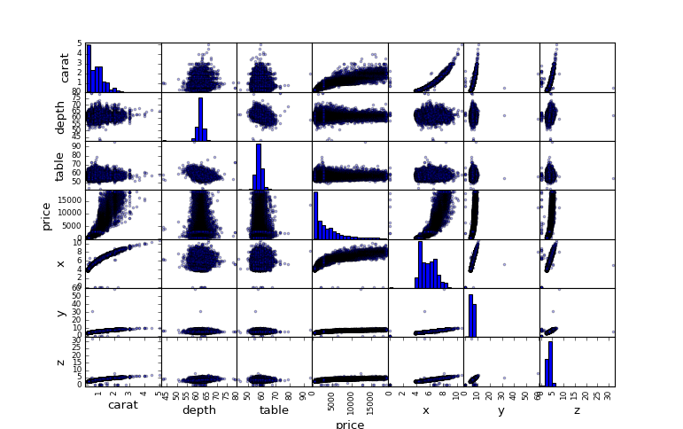

[output not shown]

```python
pd.tools.plotting.scatter_matrix(da, alpha = 0.2, hist_kwds = {"bins": 20})
```

## Statsmodels (1.1.1): Linear Regression Theory

- Goal: We aim to study the relationship between a dependent variable $y$ and $p$ indepedent variables $x_1, x_2,\cdots, x_p$.
- Model of Linear Regression: $y = \beta_0 + x_1\beta_1 + x_2\beta_2 + \cdots + x_p\beta_p + \varepsilon$
- Components:
  - $\beta_0$: intercept of $y$ when $x_1, x_2,\cdots, x_p$ are all 0
  - $\beta_j$: slope of $x_j$ on $y$, $j = 1, 2, \cdots, p$
  - $\varepsilon$: random error of $y$ in each observation
- Prediction: To predict $y_i$, if we know $\hat{\beta} = (\hat{\beta}_0, \hat{\beta}_1, \cdots, \hat{\beta}_p)^T$ and $x_i = (1, x_{i1}, x_{i2}, \cdots, x_{ip})$ from data, we can predict $y_i$ with $\hat{y}_i = x_i\hat{\beta} = \hat{\beta}_0 + x_{i1}\hat{\beta}_1 + \cdots + x_{ip}\hat{\beta}_p$
- Method: To solve $\hat{\beta}$, we can use ordinary least squares (OLS): $\min_{\beta}\sum_i^n(y_i - x_i\beta)^2$, when iid normal assumption of random error $\varepsilon_i \sim^{iid} N(0,\sigma^2),\quad \sigma^2 > 0$ is satisfied.

## Statsmodels (1.1.2): Linear Regression (Formula-Form)

```python
import statsmodels.formula.api as smf
model_lm1 = smf.ols("price ~ carat + depth", data = dac).fit()
print(model_lm1.summary())
```

```
                            OLS Regression Results
==============================================================================
Dep. Variable:                  price   R-squared:                       0.853
Model:                            OLS   Adj. R-squared:                  0.853
Method:                 Least Squares   F-statistic:                 1.154e+05
Date:                Mon, 12 Dec 2016   Prob (F-statistic):               0.00
Time:                        22:57:53   Log-Likelihood:            -3.4751e+05
No. Observations:               39708   AIC:                         6.950e+05
Df Residuals:                   39705   BIC:                         6.950e+05
Df Model:                           2
Covariance Type:            nonrobust
==============================================================================
                 coef    std err          t      P>|t|      [95.0% Conf. Int.]
------------------------------------------------------------------------------
Intercept   4046.2863    329.513     12.280      0.000      3400.433  4692.140
carat       7779.7895     16.192    480.475      0.000      7748.053  7811.526
depth       -102.4020      5.337    -19.189      0.000      -112.862   -91.942
==============================================================================
Omnibus:                    10141.607   Durbin-Watson:                   1.016
Prob(Omnibus):                  0.000   Jarque-Bera (JB):            88130.856
Skew:                           0.984   Prob(JB):                         0.00
Kurtosis:                      10.028   Cond. No.                     2.65e+03
==============================================================================

Warnings:
[1] Standard Errors assume that the covariance matrix of the errors is correctly specified.
[2] The condition number is large, 2.65e+03. This might indicate that there are
strong multicollinearity or other numerical problems.
```

## Statsmodels (1.2.1): Linear Regression (Matrix-Form)

- If we have $n$ observations, we can write $y = \beta_0 + x_1\beta_1 + x_2\beta_2 + \cdots x_p\beta_p + \varepsilon$ into:
- Matrix Form of Linear Regression: $Y = X\beta + \varepsilon$.
  - row $i$ is $i$th observation, column $j$ is $j$th variable
  - $Y_{n\times1} = (y_1, y_2, \cdots, y_n)^T$,
  - $\varepsilon_{n\times1} = (\varepsilon_1, \varepsilon_2, \cdots, \varepsilon_n)^T$, $\varepsilon_i \sim^{iid} N(0,\sigma^2),\quad \sigma^2 > 0$
  - $X_{n\times(p+1)} = (1, X_1, X_2, \cdots, X_p)$, For each variable $X_j = (X_{1j}, X_{2j}, \cdots, X_{nj})^T$
  - $\beta_{(p+1)\times1} = (\beta_0, \beta_1, \beta_2, \cdots, \beta_p)^T$
- Prediction in Matrix Form: $\hat{Y} = X\hat{\beta}$
- Method (OLS) in Matrix Form: solution $\hat{\beta} = (X^TX)^{-1}X^TY$ which $\min_{\beta}(Y - X\beta)^T(Y - X\beta)$, when iid normal assumption of $\varepsilon$ is satisfied.
- If we want to use matrix-form model, we should prepare our numeric matrix X and Y before building model
- More general in machine learning field

## Statsmodels (1.2.2): Linear Regression (Matrix-Form)

```python
import statsmodels.api as sm
X = dac[["carat", "depth"]].assign(intercept = 1)
Y = dac["price"]
model_lm2 = sm.OLS(Y, X).fit()
print(model_lm2.summary())
```

```
                            OLS Regression Results
==============================================================================
Dep. Variable:                  price   R-squared:                       0.853
Model:                            OLS   Adj. R-squared:                  0.853
Method:                 Least Squares   F-statistic:                 1.154e+05
Date:                Mon, 12 Dec 2016   Prob (F-statistic):               0.00
Time:                        22:57:57   Log-Likelihood:            -3.4751e+05
No. Observations:               39708   AIC:                         6.950e+05
Df Residuals:                   39705   BIC:                         6.950e+05
Df Model:                           2
Covariance Type:            nonrobust
==============================================================================
                 coef    std err          t      P>|t|      [95.0% Conf. Int.]
------------------------------------------------------------------------------
carat       7779.7895     16.192    480.475      0.000      7748.053  7811.526
depth       -102.4020      5.337    -19.189      0.000      -112.862   -91.942
intercept   4046.2863    329.513     12.280      0.000      3400.433  4692.140
==============================================================================
Omnibus:                    10141.607   Durbin-Watson:                   1.016
Prob(Omnibus):                  0.000   Jarque-Bera (JB):            88130.856
Skew:                           0.984   Prob(JB):                         0.00
Kurtosis:                      10.028   Cond. No.                     2.65e+03
==============================================================================

Warnings:
[1] Standard Errors assume that the covariance matrix of the errors is correctly specified.
[2] The condition number is large, 2.65e+03. This might indicate that there are
strong multicollinearity or other numerical problems.
```

## How to get help

- From Function Help: ? + function
  - ?sm.OLS
  - ?model_lm2.summary
- From Autofill with *Tab*:
  - sm. + *Tab*
  - model_lm2. + *Tab*
- From Google: Your Question (what you want to do) + statsmodels
  - test statsmodels
  - mixed effect model statsmodels
- From Official Website: http://statsmodels.sourceforge.net/

## Statsmodels (1.3.1): Regression Plot

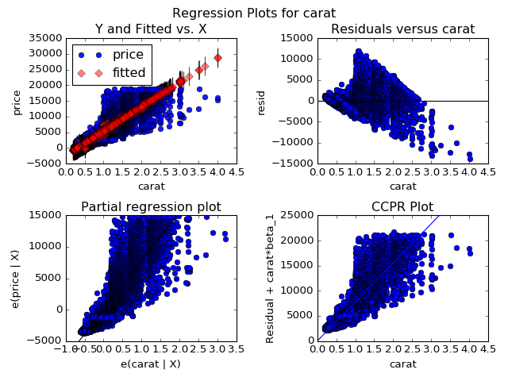

```python
sm.graphics.plot_regress_exog(model_lm1, "carat")
```

## Statsmodels (1.3.2): Residual Plot

- Goal: whether residuals $\hat{\varepsilon} = Y - \hat{Y}$ satisfy normal distribution
- A straight line indicates normal distribution of residuals

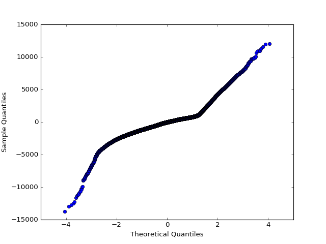

```python
sm.graphics.qqplot(model_lm1.resid)
```

## Statsmodels (2.1.1): Linear Regression with Categorical X

- $y = \beta_0 + x\beta + \varepsilon$
- If $x$ is a categorical variable, e.g. $x$ take values from group 1, group 2, group 3, ..., group $K$
- Group order may not have linear relationship with Y
- Instead of using one variable, we break categorical x into $K-1$ variables (called dummy variable):
  - $x_1$: whether $x$ is in group 1, if yes $x_1 = 1$, otherwise $x_1 = 0$
  - $x_2$: whether $x$ is in group 2, if yes $x_2 = 1$, otherwise $x_2 = 0$
  - ...
  - $x_{K-1}$: whether $x$ is in group $K-1$, if yes $x_{K-1} = 1$, otherwise $X_{K-1} = 0$
  - We needn't ask for $x_K$, if $x$ is in $x_1, \cdots, x_{K-1}$, $x$ cannot be in group $K$, vice versa.
- As a result, we write $y = \beta_0 + x_1\beta_1 + x_2\beta_2 + \cdots + x_{K-1}\beta_{K-1} + \varepsilon$, the same form as linear regression.

## Statsmodels (2.1.2): Linear Regression with Categorical X

```python
model_lm3 = smf.ols("price ~ cut + color", data = dac).fit()
print(model_lm3.summary())
```

```
                            OLS Regression Results
==============================================================================
Dep. Variable:                  price   R-squared:                       0.042
Model:                            OLS   Adj. R-squared:                  0.042
Method:                 Least Squares   F-statistic:                     173.3
Date:                Mon, 12 Dec 2016   Prob (F-statistic):               0.00
Time:                        15:51:23   Log-Likelihood:            -3.8476e+05
No. Observations:               39708   AIC:                         7.695e+05
Df Residuals:                   39697   BIC:                         7.696e+05
Df Model:                          10
Covariance Type:            nonrobust
====================================================================================
                       coef    std err          t      P>|t|      [95.0% Conf. Int.]
------------------------------------------------------------------------------------
Intercept         3535.7630    125.071     28.270      0.000      3290.620  3780.906
cut[T.Good]       -345.4368    130.737     -2.642      0.008      -601.683   -89.190
cut[T.Ideal]      -788.5209    117.557     -6.708      0.000     -1018.935  -558.107
cut[T.Premium]     294.3790    119.798      2.457      0.014        59.573   529.185
cut[T.Very Good]  -295.4528    120.707     -2.448      0.014      -532.042   -58.863
color[T.E]        -102.2167     71.837     -1.423      0.155      -243.019    38.585
color[T.F]         548.7579     72.219      7.599      0.000       407.208   690.308
color[T.G]         820.7082     70.030     11.719      0.000       683.447   957.970
color[T.H]        1200.7288     74.481     16.121      0.000      1054.745  1346.713
color[T.I]        1893.3405     82.989     22.814      0.000      1730.680  2056.001
color[T.J]        2032.2194    102.132     19.898      0.000      1832.038  2232.401
==============================================================================
Omnibus:                    10922.507   Durbin-Watson:                   0.081
Prob(Omnibus):                  0.000   Jarque-Bera (JB):            24883.118
Skew:                           1.581   Prob(JB):                         0.00
Kurtosis:                       5.245   Cond. No.                         15.8
==============================================================================

Warnings:
[1] Standard Errors assume that the covariance matrix of the errors is correctly specified.
```

## Statsmodels (2.1.3): ANOVA with Categorical X

```python
sm.stats.anova_lm(model_lm3)
```

|  | df | sum_sq | mean_sq | F | PR(>F) |
| --- | --- | --- | --- | --- | --- |
| cut | 4.0 | 8.268e+09 | 2.067e+09 | 135.293 | 5.106e-115 |
| color | 6.0 | 1.821e+10 | 3.035e+09 | 198.613 | 1.833e-250 |
| Residual | 39697.0 | 6.065e+11 | 1.528e+07 | NaN | NaN |

## Statsmodels (2.2.1): Linear Regression with Transformation and Interaction

- Model of Linear Regression: $y = x\beta + \varepsilon = \beta_0 + x_1\beta_1 + x_2\beta_2 + \cdots + x_p\beta_p + \varepsilon$
- If the relationship between $y$ and $x$ is not exactly linear:
  - Add or delete variables:
    - +: add a variable
    - -: delete a variable
    - 1: intercept term (-1: remove intercept)
  - Higher polynomial terms of $x$: $x^2, x^3, \cdots$
    - I(x ** 2), I(x ** 3), ....
  - Interaction between $x$:
    - $x_1$:$x_2$: only interaction effects between $x_1$ and $x_2$
    - $x_1$*$x_2$: both main effects and interaction effects
    - ($x_1$+$x_2$+...)**k: to formulate $k$th interaction between $x_1$, $x_2$, ...
  - Transformation of $x$ or $y$: $\log(x), x^a, 1\{x > c\}, \cdots$
    - Transformation without operator +, -, *, / or **: use function on variable in formula directly
    - Transformation with operator +, -, *, / or **: use I( ) outside the transformation to indicate it

## Statsmodels (2.2.2): Transformation and Interaction Terms

```python
model_lm4 = smf.ols("np.log(price) ~ np.log(carat) + depth * table + I(depth ** 2)", data = dac).fit()
print(model_lm4.summary())
```

```
                            OLS Regression Results
==============================================================================
Dep. Variable:          np.log(price)   R-squared:                       0.937
Model:                            OLS   Adj. R-squared:                  0.937
Method:                 Least Squares   F-statistic:                 1.174e+05
Date:                Mon, 12 Dec 2016   Prob (F-statistic):               0.00
Time:                        22:58:09   Log-Likelihood:                -2132.6
No. Observations:               39708   AIC:                             4277.
Df Residuals:                   39702   BIC:                             4329.
Df Model:                           5
Covariance Type:            nonrobust
=================================================================================
                    coef    std err          t      P>|t|      [95.0% Conf. Int.]
---------------------------------------------------------------------------------
Intercept        11.0096      1.422      7.742      0.000         8.222    13.797
np.log(carat)     1.6937      0.002    753.894      0.000         1.689     1.698
depth             0.2559      0.034      7.605      0.000         0.190     0.322
table            -0.3114      0.018    -17.398      0.000        -0.346    -0.276
depth:table       0.0048      0.000     16.555      0.000         0.004     0.005
I(depth ** 2)    -0.0046      0.000    -20.929      0.000        -0.005    -0.004
==============================================================================
Omnibus:                      569.138   Durbin-Watson:                   1.309
Prob(Omnibus):                  0.000   Jarque-Bera (JB):              929.613
Skew:                           0.128   Prob(JB):                    1.37e-202
Kurtosis:                       3.704   Cond. No.                     5.79e+06
==============================================================================

Warnings:
[1] Standard Errors assume that the covariance matrix of the errors is correctly specified.
[2] The condition number is large, 5.79e+06. This might indicate that there are
strong multicollinearity or other numerical problems.
```

## Statsmodels (2.2.3): Formula Transformation to Matrix Form

```python
import patsy as ps
X = ps.dmatrix(" ~ np.log(carat) + depth * table + I(depth ** 2)", data = dac, return_type = "dataframe")
model_lm5 = sm.OLS(Y, X).fit()
print(model_lm5.summary())
```

```
                            OLS Regression Results
==============================================================================
Dep. Variable:                  price   R-squared:                       0.739
Model:                            OLS   Adj. R-squared:                  0.739
Method:                 Least Squares   F-statistic:                 2.244e+04
Date:                Mon, 12 Dec 2016   Prob (F-statistic):               0.00
Time:                        22:58:12   Log-Likelihood:            -3.5897e+05
No. Observations:               39708   AIC:                         7.179e+05
Df Residuals:                   39702   BIC:                         7.180e+05
Df Model:                           5
Covariance Type:            nonrobust
=================================================================================
                    coef    std err          t      P>|t|      [95.0% Conf. Int.]
---------------------------------------------------------------------------------
Intercept     -4.335e+04   1.14e+04     -3.813      0.000     -6.56e+04 -2.11e+04
np.log(carat)  5941.8360     17.960    330.843      0.000      5906.635  5977.037
depth          2683.6348    268.963      9.978      0.000      2156.460  3210.810
table          -896.8046    143.080     -6.268      0.000     -1177.244  -616.365
depth:table      13.2681      2.321      5.715      0.000         8.718    17.818
I(depth ** 2)   -29.2568      1.754    -16.684      0.000       -32.694   -25.820
==============================================================================
Omnibus:                     9388.619   Durbin-Watson:                   0.271
Prob(Omnibus):                  0.000   Jarque-Bera (JB):            22866.825
Skew:                           1.312   Prob(JB):                         0.00
Kurtosis:                       5.634   Cond. No.                     5.79e+06
==============================================================================

Warnings:
[1] Standard Errors assume that the covariance matrix of the errors is correctly specified.
[2] The condition number is large, 5.79e+06. This might indicate that there are
strong multicollinearity or other numerical problems.
```

## Statsmodels (3.1): Generalized Linear Model Theory

- If $\varepsilon$ are not iid normal distributed, e.g. Y has 0, 1 binary values
- Generalized Linear Model: $g(E(Y)) = X\beta$
  - $E(Y)$: conditional expectation of $Y$ given $X$
  - $g(\cdot)$: link function
    - Related with $Q(\theta)$ in (canonical form) exponential family distribution $f(y|\theta) = A(y)\cdot B(\theta)\cdot e^{yQ(\theta)}$
    - $g(y) = y$: Linear regression with normal distribution
    - $g(y) = \log(\frac{y}{1-y})$: Logistic regression with binomial distribution
    - $g(y) = \log(y)$: Poission regression with Poission distribution
  - $X\beta$: linear component, same as linear regression
- Prediction: $\hat{Y} = g^{-1}(X\hat{\beta})$
- Method: To solve $\hat{\beta}$, use maximum likelihood estimator (MLE): $\max_{\beta}\prod_{i=1}^nf(y_i|\theta = \hat{y}_i) = \max_{\beta}\sum_{i=1}^n\log f(y_i|g^{-1}(X_i\beta))$

## Statsmodels (3.2): Generalized Linear Model

```python
Y = (dac["price"] > 10000).astype("int8")
pd.value_counts(Y)
```

```
0    35881
1     3827
Name: price, dtype: int64
```

```python
model_glm = sm.GLM(Y, X, family=sm.families.Binomial()).fit()
print(model_glm.summary())
```

```
                 Generalized Linear Model Regression Results
==============================================================================
Dep. Variable:                  price   No. Observations:                39708
Model:                            GLM   Df Residuals:                    39702
Model Family:                Binomial   Df Model:                            5
Link Function:                  logit   Scale:                             1.0
Method:                          IRLS   Log-Likelihood:                -4196.6
Date:                Mon, 12 Dec 2016   Deviance:                       8393.3
Time:                        22:58:25   Pearson chi2:                 1.94e+04
No. Iterations:                    11
=================================================================================
                    coef    std err          z      P>|z|      [95.0% Conf. Int.]
---------------------------------------------------------------------------------
Intercept      -340.0505     54.556     -6.233      0.000      -446.979  -233.122
np.log(carat)    10.0100      0.162     61.938      0.000         9.693    10.327
depth            10.9339      1.363      8.023      0.000         8.263    13.605
table             0.3614      0.540      0.669      0.503        -0.697     1.420
depth:table      -0.0081      0.009     -0.922      0.357        -0.025     0.009
I(depth ** 2)    -0.0868      0.009    -10.144      0.000        -0.104    -0.070
=================================================================================
```

```python
'''
The Words of Agur


    Surely I am too stupid to be a man.

        I have not the understanding of a man.

    I have not learned wisdom,

        nor have I knowledge of the Holy One.

    Who has ascended to heaven and come down?

        Who has gathered the wind in his fists?

    Who has wrapped up the waters in a garment?

        Who has established all the ends of the earth?

    What is his name, and what is his son's name?

        Surely you know!



(Proverbs 30:2-4 ESV)
'''
```

# Scikit-learn for Machine Learning

## What is Scikit-learn?

- Scikit-learn: Machine Learning in Python
  - Simple and efficient tools for data mining and data analysis
  - Accessible to everybody, and reusable in various contexts
  - Built on NumPy, SciPy, and matplotlib
  - Open source, commercially usable - BSD license
- Features:
  - Classification
  - Regression
  - Clustering
  - Dimensionality reduction
  - Model selection
  - Preprocessing

Reference: [Scikit-learn official site](http://scikit-learn.org/stable/)

## Contents

1. Machine Learning Theory
   - Loss Function
   - Training-Validation Sets
   - Cross-Validation
2. An Example for CV Training: Linear Regression
3. Over-fitting
   - Penalty Function
   - Ridge and Lasso
   - Select Penalty Coeffient
4. Tree-based Models
   - Decision Tree
   - Random Forest
   - Gradient Boosting Trees

## Scikit-learn (0) Prepare Data

```python
# Load modules and set options
import numpy as np
import pandas as pd
import matplotlib.pyplot as plt

np.set_printoptions(precision = 3)
pd.set_option('precision', 3)
%matplotlib notebook
%cd ~/Stat
```

```
/Users/fangda/Stat
```

```python
# Load price-missing data and true label data
da = pd.read_csv("Diamonds.csv", index_col = "n")
da_true = pd.read_csv("Diamonds_predict_true.csv", index_col = "n")
da.shape, da_true.shape
```

```
((53940, 10), (14232, 10))
```

```python
# Separate X and Y
Y, X = da['price'], da.drop('price', axis = 1)
Y.shape, X.shape
```

```
((53940,), (53940, 9))
```

```python
# Denote labeled and unlabeled row index
ir_unlab, ir_lab = da.index[Y.isnull()], da.index[~Y.isnull()]
ir_unlab.shape, ir_lab.shape
```

```
((14232,), (39708,))
```